# Lab 4, Zad 2

# Analiza wyników dla róznych parametrów

Przetestowałem generowanie funkcji dla różnej wartości początkowej temperatury. Jest to parametr, który najmocniej wpływa na sposób generowania oraz najłatwiej będzie go omówić

Przykładowe obraz dla temp_start = 1

Chess, size = 128, $δ = $ 0.4, iter = 100000

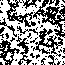

big_chess, size = 512, $δ = $ 0.6, iter = 100000

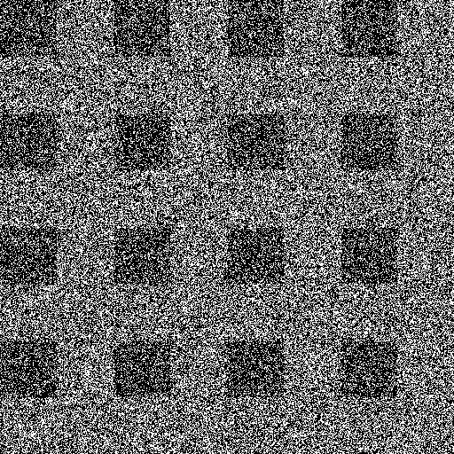

#### Obrazy dla temp_start = 30

Chess, size = 128, $δ = $ 0.4, iter = 100000

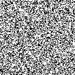

big_chess, size = 512, $δ = $ 0.6, iter = 100000

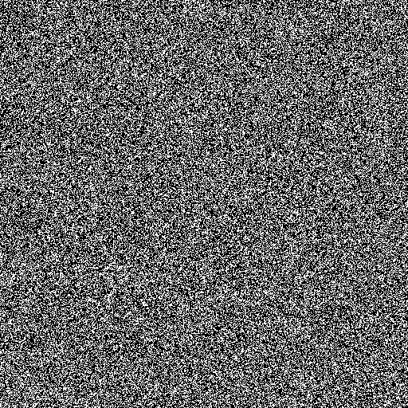

Po przeanalizowaniu wygenerowanych materiałów można stwierdzić, że wysoka temperatura wprowadza znaczące zaszumienie do obrazu. Patterny i struktury, które są wyraźnie widoczne przy niższej temperaturze, stają się praktycznie niezauważalne i rozmywają się w chaosie szumu przy wyższych wartościach temperatury.

Ale jest jedna struktura, której jakość nie pogorszyła się wraz z dużym wzrostem temperatury początkowej. Jest nią struktura Center

Przykładowe obraz dla temp_start = 1

Center, size = 256, $δ = $ 0.1, iter = 100000

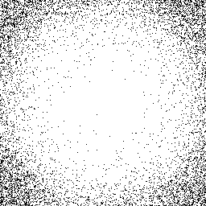

Obrazy dla temp_start = 30

Center, size = 256, $δ = $ 0.1, iter = 100000

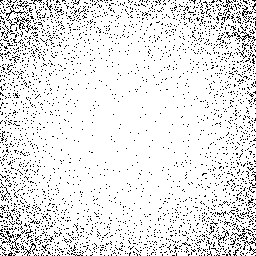

Oba obrazy są do siebie bardzo podobne, z drobną przewagą obrazu uzyskanego przy temp_start = 1, biorąc pod uwagę liczbę pojedynczych elementów w centrum. W tym przypadku zaszumienie nie wpłynęło negatywnie na obraz, a wręcz dodało mu pewnego kolorytu, wzbogacając całość o interesujące detale.

# Wykresy funkcji optymalizowanych

Przygladnijmy się wykresom funkcji optymalizowanych

Widać dwie wyraźne tendencje:

- Dla wysokiej temperatury, funkcja optymalizowana przyjmuje bardzo nieregularny przebieg, co może wskazywać na większą podatność na szum i brak stabilności w procesie optymalizacji.
- Dla niskiej temperatury, wykres staje się bardziej gładki, co sugeruje, że algorytm koncentruje się na bardziej stabilnych i precyzyjnych rozwiązaniach, jednak może również utknąć w lokalnych minimach, przez co optymalizacja staje się mniej dynamiczna.

Dodatkowo, można zauważyć, że im mniejsza mapa, tym wykres staje się bardziej chaotyczny. W przypadku mniejszych przestrzeni optymalizacyjnych, algorytm może napotkać większe trudności w znajdowaniu stabilnych rozwiązań, co prowadzi do bardziej losowych i nieregularnych wyników, zanim osiągnie bardziej jednolity stan w miarę zmniejszania temperatury.

Porównanie wykresów dla różnych temperatur:

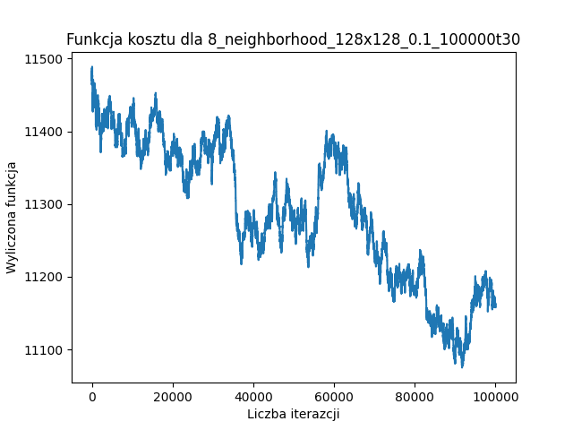

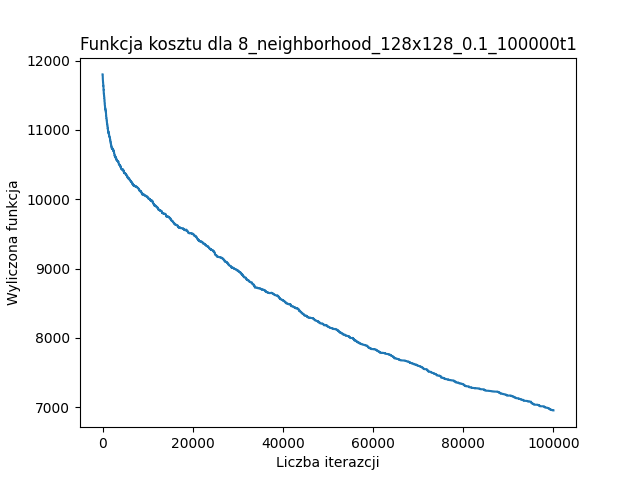

Porównanie dla wzrastających wymiarów obrazu

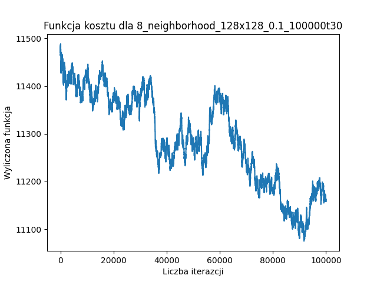

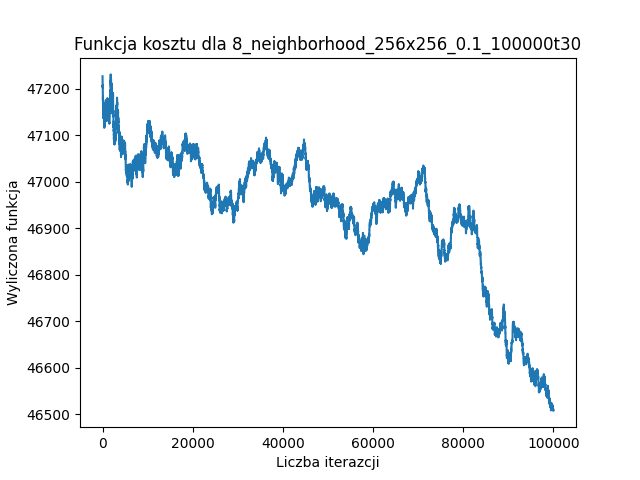

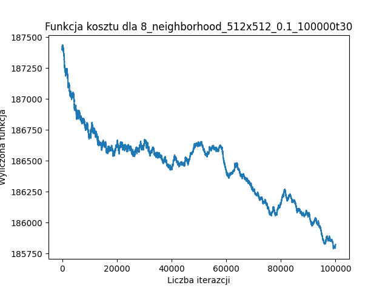

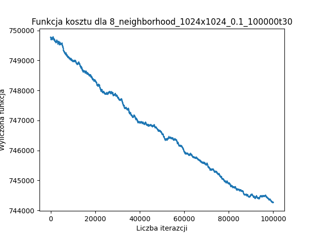

Wraz ze wzrostem wielkości obrazka, zmienność zanika

Jedynym odstępstwem od tej zasady jest ponownie wykres funkcji dla *center*, który we wszystkich warunkach przyjmuje ten sam charakterystyczny kształt:

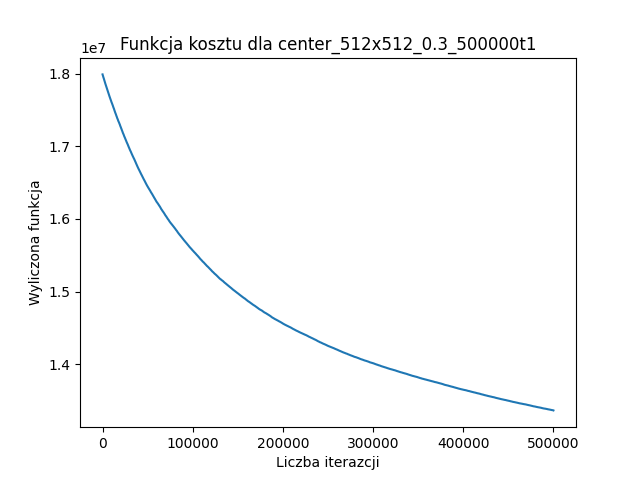

# Podsumowanie

- Algorytm wyżarzania okazał się niezwykle skutecznym narzędziem do generowania struktur przypominających kryształy.
- Najlepsze rezultaty osiągnięto przy zastosowaniu wykładniczej funkcji temperatury.
- Dzięki wykorzystaniu różnych funkcji optymalizacyjnych udało się uzyskać interesujące i zróżnicowane obrazy.
- Niestabilność wynikająca z wysokiej temperatury początkowej została zniwelowana przez rosnące wymiary obrazów.
- Wysoka temperatura początkowa w wielu przypadkach prowadziła do powstania dużego chaosu w obrazie, który ostatecznie zamieniał się w zwykły szum.
- Dla obrazów typu center, zwiększona temperatura początkowa wprowadzała jedynie niewielki poziom szumu, w przeciwieństwie do pozostałych wzorców.